# Predicting Elections

## In-class questions: 3/7/2016

If you have small technical questions during class, go to this [link](https://docs.google.com/document/d/1Lz0NsFsgE9ZgKnIQrJp-kt2d3rx0xWRZB23-pdZpsfY/edit?usp=sharing) and ask away.

## 2008 Presidential Election (Obama vs McCain)

We are going to put together the concepts we have learned related to modeling polls. For this, we will continue to use the 2008 presidential election as an example. We have previously shown how to scrape the data from [this](http://www.pollster.com/08USPresGEMvO-2.html) web site.

```r
library(XML)
theurl <- paste0("http://www.pollster.com/08USPresGEMvO-2.html")
html_tables <- readHTMLTable(theurl,stringsAsFactors=FALSE)
tab <- html_tables[[1]]
```

## Wrangling the data

We have already discussed in detail how to scrape and wrangle this particular data set in the  
models.Rmd in the 2016 GitHub repository. We used the `tidyr`, `stringr` and `lubridate` packages. Here, I have combined all the steps from the models.Rmd into one step.

```r
library(dplyr)
library(tidyr)
library(stringr)
library(lubridate)

tab <- tbl_df(tab)
tab <- tab %>%
            separate(col=Dates, into=c("start_date","end_date"),
                     sep="-", fill="right") %>%
            mutate(end_date = ifelse(is.na(end_date), start_date, end_date)) %>%
            separate(start_date, c("smonth", "sday", "syear"), sep = "/",
                    convert = TRUE, fill = "right") %>%
            mutate(end_date = ifelse(str_count(end_date, "/") == 1,
                                     paste(smonth, end_date, sep = "/"), end_date)) %>%
            mutate(end_date = mdy(end_date)) %>%
            mutate(syear = ifelse(is.na(syear), year(end_date), syear + 2000)) %>%
            unite(start_date, smonth, sday, syear) %>%
            mutate(start_date = mdy(start_date)) %>%
            select(-Barr, -Nader, -Other, -Undecided, -Margin) %>%
            separate(`N/Pop`, into=c("N","population_type"), sep=" ",
                convert=TRUE, fill="left") %>%
            mutate(Obama = as.numeric(Obama)/100,
              McCain=as.numeric(McCain)/100,
              diff = Obama - McCain,
              day=as.numeric(start_date - mdy("11/04/2008")),
              week = floor(day/7))
```

## Using Hierarchical Model to Predict Polls

Last week, we introduced hierarchical models as a tool to estimate the posterior distribution of the [batting average of Jose Iglesias](https://github.com/datasciencelabs/2016/blob/master/lectures/models/bayes.Rpres).

As a brief summary of using hierarchical models, you build a model before seeing polls (the prior distribution):  
$\theta \sim N(\mu, \tau^2)$

The you start seeing poll data (the sampling distribution):

$Y | \theta \sim N(\theta, \sigma^2)$

We update our prediction (the posterior distribution):

$\begin{eqnarray*} \mbox{E}(\theta|y) &=& \mu + (1-B)(Y-\mu) \mbox{ with }B &=& \frac{\sigma^2}{\sigma^2+\tau^2}\\ \\ \mbox{var}(\theta\mid y) &=& \frac{1}{1/\sigma^2+1/\tau^2} \end{eqnarray*}$

That is a lot information stuffed into three steps. Let’s break the steps down individually and apply the theory to the 2008 Presidential Election poll data to see how it works.

### Prior belief

The first step is to define our *prior belief* that Obama will beat McCain. We define a model (*a prior*) before seeing polls for the difference between `Obama` and `McCain` (which we define as $\theta$):

$\theta \sim N(\mu, \tau^2)$

To quantify this belief, we must define values for $\mu$ and $\tau$.

#### Assessment

Say before seeing any poll data, you have no idea who is going to win.  
What should $\mu$ be? What about $\tau$?

**Your answer here**: Because we have no prior idea who will win, the prior mean $\mu$ should be 0. And again, we do not know anything about the data, so $\tau$ should be big.

Now, let’s assume we are part of the republican party and we passionately believe that McCain will beat Obama. To quantify this belief, we can say the distribution of $\theta$ is normal with mean $\mu = -0.15$ and standard deviation $\tau = 5$.

#### Assessment

Under your prior belief that McCain will beat Obama, what is the probability that Obama will beat McCain in the 2008 presidential election?

```r
##Your code here

mu_prior = -0.15
tau_prior = 5
1 - pnorm(0,mu_prior,tau_prior)
```

```
## [1] 0.4880335
```

### Observed data (sampling distribution)

[Last week, we learned about how we have been implicitly using linear models in this course](https://github.com/datasciencelabs/2016/blob/master/lectures/inference/models.pdf). We have been doing this by trying to estimate the probability of tossing a coin and observing a head, the proportion of blue beads in a jar, the average height of a population, and the difference in the proportion of votes two candidates, for example Obama and McCain, will receive. The goal of using linear models is to try and estimate some parameter $\theta$ by observing draws from a sampling model.  
The first linear model we considered was:

$Y_i = \theta + \varepsilon_i, i = 1, ..., N$

where $Y_1, Y_2, \ldots, Y_N$ are the observed values with $N$ total observations. Each observation has an *error* term $\varepsilon_i$ that defines the difference between the true parameter value ($\theta$) and the observed value ($Y_i$). We assume that the expected value of the error term is 0 and very often assume the standard deviation is a contant $\sigma$.

Up until now, we have not used the poll data. We have only made statements about our prior beliefs. Now assume you start seeing the poll data. Let $Y$ be the observed difference in the polls between Obama and McCain. We define the sampling distribution as

$Y | \theta \sim N(\theta, \sigma^2/N)$

where

- $Y$ is the observed difference in each poll between Obama and McCain
- $\theta$ is the true difference in the polls on election night
- $\sigma^2$ is the observed sample variance
- $N$ is the number of polls we observe (i.e. each poll is an observation here)

#### Estimate $\theta$

Using our linear model defined above, we have seen how to use the method called [*least squares*](https://en.wikipedia.org/wiki/Least_squares), which minimizes the least squares equation:

$\sum_{i=1}^N (Y_i - \theta)^2$

to obtain the *least squares estimate* (LSE), which is basically a sample average of the individual observed polls:

$\hat{\theta} = \frac{1}{N}\sum_{i=1}^N Y_i = \bar{Y}$

Now, what is $\sigma$?

#### Estimate $\sigma$ using Central Limit Theorem (theoretical) versus the sample standard deviation (empirical)

We have learned that in the context of estimating the difference in the polls between two presidentical candidates, we can use the Central Limit Theorem (CLT) to model $\varepsilon$. According to the CLT,

$\varepsilon \sim \mbox{Normal}\left(0, \frac{2\sqrt{p (1-p)}}{\sqrt{n}}\right)$

where $p$ is the prorportion for Obama, $n$ is the poll size from a single poll. This means statistical theory tells us the expected value of $\varepsilon$ is 0 and the standard deviation $\sigma$ should be given by $\frac{2\sqrt{p (1-p)}}{\sqrt{n}}$.

Remember, if $p$ represented the percentage for just one candidate (e.g. Obama), the statitical theory tells us that the standard error for the estimate of the percentage for Obama is

$\frac{\sqrt{p (1-p)}}{\sqrt{n}}$

But if we are estimating the difference in percentages between two candidates, then the estimate is approximated by $\hat{\theta} = \hat{p} - (1-\hat{p}) = 2\hat{p} - 1$. This implies that the standard error is $2 \sqrt{ p (1 - p)} / \sqrt{n}$.

Because each $Y_i$ a separate poll then the standard deviation of $\varepsilon$ should be about $2 \sqrt{ p (1 - p) }/ \sqrt{n}$:

**Note, this theory is extremely useful when we just have one poll.**

**However**, if we are fortunate enough to be able to observe mutliple polls results (e.g. polls from different pollsters or polls from different weeks over time), we can use the poll data directly to estimate $\sigma$ (instead of using the statistical theory above). The typical strategy is to use the sample standard deviation formula:

$s = \sqrt{ \frac{1}{N-1}\sum_{i=1}^N (Y_i - \bar{Y})^2}$

where $N$ is the total number of polls we observe.

**IMPORTANT**: Do not confuse the poll sample size $n$ with the number of observations in our model above $N$. In the model above we treat each poll as a single observation and we observe $N$ polls. But it is important to keep in mind that each poll we observe had a poll size associated with it (i.e. $n$).

### Explore the data to estimate $\theta$ and $\sigma$

Next we are going to explore and use the 2008 presidential election poll data to try and estimate $\theta$ and $\sigma$.

#### Assessment

Assume today is Jan 1, 2008. Use all the poll data up until today to provide an estimate for $\theta$ and an estimate of the standard deviation $\sigma$ (empirically or from the data and not using the statistical theory from the CLT).

```r
##Your code here.

tab %>%
    filter(start_date<"2008-01-01") %>%
    summarize(theta_hat = mean(diff), sigma_hat = sd(diff))
```

```
## Source: local data frame [1 x 2]
##
##    theta_hat  sigma_hat
##        (dbl)      (dbl)
## 1 0.02269231 0.05339881
```

Last week, we also a scatter plot showing the number of polls (y-axis) for each week (x-axis).

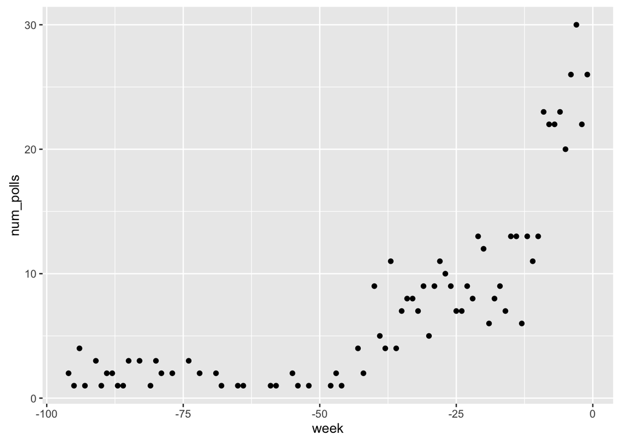

```r
library(ggplot2)
tab %>%
    group_by(week) %>%
    summarize(num_polls=n()) %>%
    ggplot(aes(week, num_polls)) + geom_point()
```

Many of the polls 50 weeks prior to the election only had a handful of polls.

#### Assessment

In which weeks before the election were there at least five or more polls in a given week.

```r
##Your code here.

tab %>%
    group_by(week) %>%
    summarize(num_polls=n()) %>%
    filter(num_polls >= 5)
```

```
## Source: local data frame [38 x 2]
##
##     week num_polls
##    (dbl)     (int)
## 1    -40         9
## 2    -39         5
## 3    -37        11
## 4    -35         7
## 5    -34         8
## 6    -33         8
## 7    -32         7
## 8    -31         9
## 9    -30         5
## 10   -29         9
## ..   ...       ...
```

#### Assessment

Assume today is 30 weeks away from the 2008 election. Extract the polls that occurred between Jan 1, 2008 and 30 weeks prior to the election (i.e. Assume we do not trust any polls that occurred too far out). Remove polls from weeks that do not have at least 5 polls. Provide an estimate for $\theta$ called `theta_hat` and an estimate of the standard deviation $\sigma$ called `sigma_hat`. In addition record the number of total number of polls and call it `tot_poll`. We will use these estimates for our sampling distribution. Save your estimates into a table called `tabEst`.

**Hint**: You will need to group the polls by week using `group_by()`. After you have filtered for the poll criteria, use `ungroup()` before estimating the mean and standard deviation.

```r
##Your code here.

tabEst <- tab %>%
    filter(start_date>"2008-01-01" & week <= -30) %>%
    group_by(week) %>%
    mutate(num_polls=n()) %>%
    filter(num_polls >= 5) %>%
    ungroup() %>%
    summarize(theta_hat = mean(diff),
              sigma_hat = sd(diff),
              tot_poll = n())
tabEst
```

```
## Source: local data frame [1 x 3]
##
##     theta_hat  sigma_hat tot_poll
##         (dbl)      (dbl)    (int)
## 1 0.006521739 0.04341408       69
```

#### Assessment

Use the Central Limit Theorem to construct a confidence interval for $\hat{\theta}$ using the empirical approach to estimate the standard deviation $\sigma$.

```r
##Your code here

tabEst$theta_hat +
    c(-1,1) * (tabEst$sigma_hat / sqrt(tabEst$tot_poll)) * qnorm(0.975)
```

```
## [1] -0.003721898  0.016765376
```

#### Assessment

```r
##Your code here

1 - pnorm(0, tabEst$theta_hat,
          tabEst$sigma_hat / sqrt(tabEst$tot_poll))
```

```
## [1] 0.8939543
```

#### Compare the empirical estimate $\sigma$ to the theoretical estimate of $\sigma$ using Central Limit Theorem

Until now, we have been using the sample standard deviation to estimate $\sigma$ (i.e. empirically). Now let’s compare how the empirical estimate of $\sigma$ compares to the theoretical estimate of $\sigma$ using the statistical theory that we’ve learned.

Let’s filter the polls for only polls within 5 weeks of the election and for polls that had a sample size of 1000. We can use boxplots to plot the distribution of the difference between Obama and McCain stratified by pollster.

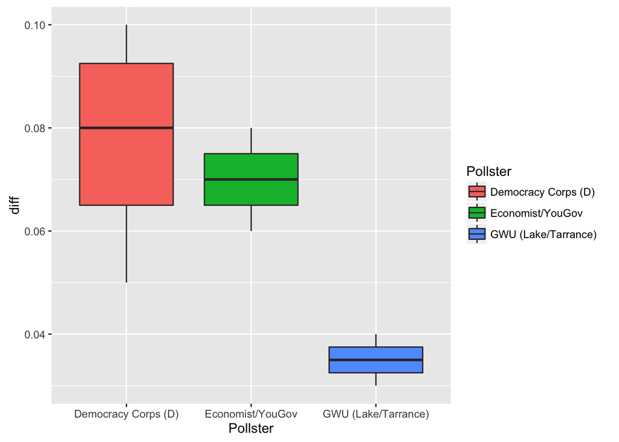

```r
tab %>%
    filter(week>-5, N == 1000) %>%
    ggplot(aes(Pollster, diff, fill=Pollster)) + geom_boxplot()
```

If you recall above, we discussed how use the statistical theory from the Central Limit Theorem (CLT) to estimate $\sigma$. According to the CLT,

$\varepsilon \sim \mbox{Normal}\left(0, \frac{2\sqrt{p (1-p)}}{\sqrt{n}}\right)$

where $n$ is the poll size. This means statistical theory tells us the expected value of $\varepsilon$ is 0 and the standard deviation $\sigma$ should be given by $\frac{2\sqrt{p (1-p)}}{\sqrt{n}}$.

#### Assessment

```r
##Your code here.

tab %>%
    filter(start_date>"2008-01-01" & N == 1000) %>%
    summarize(total_polls = n(),
              poll_size = unique(N),
              theta_hat = mean(diff),
              sigma_hat_theoretical = 2*sqrt(mean(Obama)*(1-mean(Obama))) / sqrt(unique(N)))
```

```
## Source: local data frame [1 x 4]
##
##   total_polls poll_size  theta_hat sigma_hat_theoretical
##         (int)     (int)      (dbl)                 (dbl)
## 1          53      1000 0.02320755            0.03140566
```

#### Assessment

$s = \sqrt{ \frac{1}{N-1}\sum_{i=1}^N (Y_i - \bar{Y})^2}$

How does it compare to the estimate of $\sigma$ above using the CLT?

```r
##Your code here.

tab %>%
    filter(start_date>"2008-01-01" & N == 1000) %>%
    summarize(total_polls = n(),
              poll_size = unique(N),
              theta_hat = mean(diff),
              sigma_hat_theor = 2*sqrt(mean(Obama)*(1-mean(Obama))) / sqrt(unique(N)),
              sigma_hat_emp = sd(diff))
```

```
## Source: local data frame [1 x 5]
##
##   total_polls poll_size  theta_hat sigma_hat_theor sigma_hat_emp
##         (int)     (int)      (dbl)           (dbl)         (dbl)
## 1          53      1000 0.02320755      0.03140566    0.04103346
```

### Why does the theory not match what we see in the data?

In general, if the model is a good fit to the data, the empirical estimate of $\sigma$ should match what the the statistical theory says it should be. Recall this is our model:

$Y_i = \theta + \varepsilon_i, i = 1, ..., N$

Instead, we see the empirical estimate of $\sigma$ is larger than what the theory says it should be. Why is this??

Well, there are many possible reasons for this. Let’s consider three reasons:

#### 1. Time effect

One possible reason is that if there is a strong time (or “week”) effect, then there is extra variability in the data that is not being accounted for in the model.

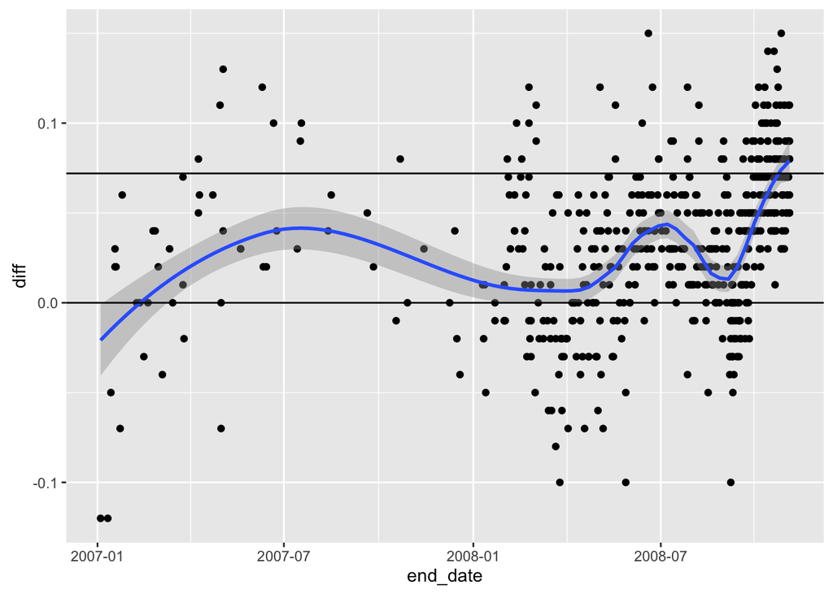

```r
tab %>%
    ggplot(aes(end_date, diff)) + geom_point() +
        geom_smooth(span=0.5) + geom_hline(aes(yintercept=0)) +
        geom_hline(aes(yintercept=0.072))
```

We could modify the model to include another term $w_t$ that represents the time (or “week”) effect.

$Y_{t,i} = \theta + w_t + \varepsilon_{t,i}$

**Note**: We now have two indexes $t$ denoting week and $i$ an index for the $i$-th poll during week $t$.

By including this extra term in our model, we are saying that the variability observed in the polls does not just come from $\varepsilon$. We are saying there is extra or additional variabilty from time that we are ignoring.

We can model the time effects $w_t$ by making assumptions about the expected value and variance of of $w_t$. For example, we could model this as a fixed effect and estimate it, for example, [loess](https://en.wikipedia.org/wiki/Local_regression). This is not that useful for forecasting as we don’t know if the trend will continue. More useful is to model it as a random effect with its variance depending on days left to the election (e.g. a model with a decreasing variance as the weeks get closer to the election.

To incorporate information about the time effect, we an use the fact that we see the variance in the difference between Obama and McCain decreases as we get closer to election night.

If we are 10 weeks away from election night, you can get an idea of the standard deviation of $w_t$ by looking at 10 weeks prior on previous elections. In previous elections we observe $\theta$ so we can actually observe $w_t$ + $\varepsilon$. We can observe the this for several weeks and notice that it gets smaller and smaller as the election gets closer.

#### 2. House effect

Another possible reason is from what’s called a *house effect* or pollster effect. If there was no pollster effect, we would expect the distributions (or boxplots) of the difference between Obama and McCain to be similar.

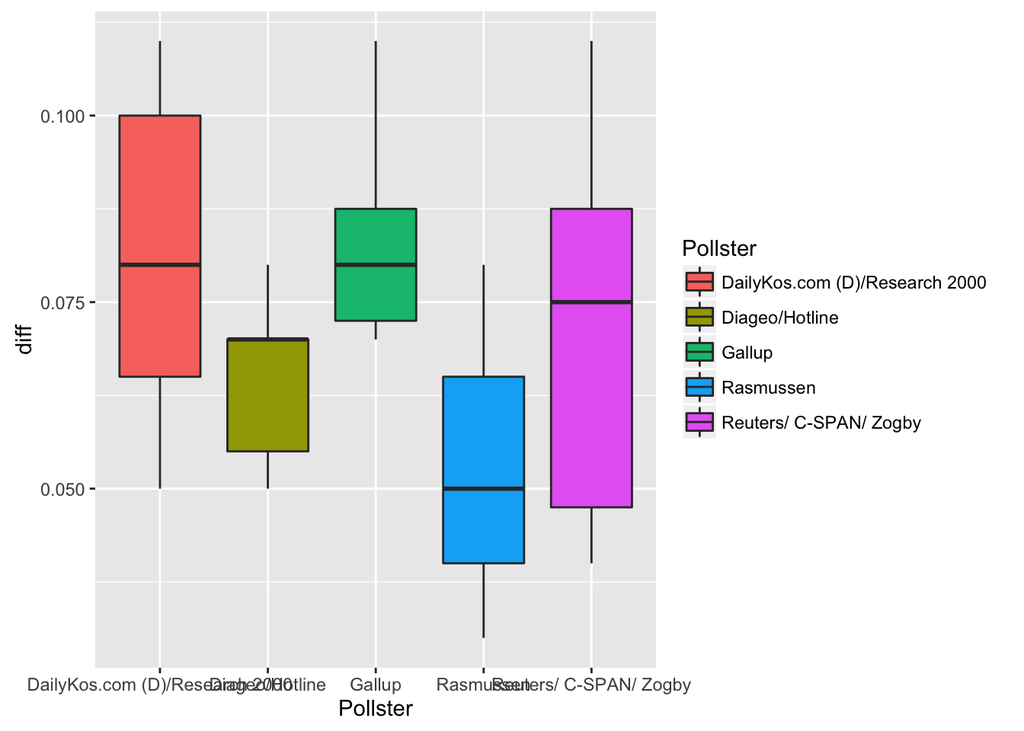

```r
tab %>%
    filter(week > -4) %>%
    group_by(Pollster) %>%
    filter(n()>4) %>%
    ggplot(aes(Pollster, diff , fill=Pollster)) + geom_boxplot()
```

We see that each pollster has a different distribution in the difference between Obama and McCain. We could modify the model to include another term $p_j$ that represents the pollster effect.

$Y_{t,i,j} = \theta + w_t + p_{j} + \varepsilon_{t,i,j}$

where $p_{j}$ a pollster effect for the $j^{th}$ pollster. By including this extra term in our model, we are saying that the variability observed in the polls does not just come from $\varepsilon$. We are saying there is extra or additional variabilty from the pollsters.

We can model the pollster specific effects $p_j$ by making an assumption about the expected value of $p_j$ (e.g. $\mbox{E}(p_j)=0$) and we can model the pollster specific effects to have different variances. To estimate these we can use previous election data. With these in place, we can construct weighted estimates for $\theta$ that better estimate the variablity.

#### 3. General biases

The last possible reason we’ll consider here is from what are called *general biases* that have not been accounted for. Specifically, our assumption that $\mbox{E}(p_j)=0$ is incorrect. This assumption says that, on average, pollsters are not biased, but this is not the case. Instead we need to add a general bias to the model

$Y_{t,i,j} = \theta + w_t + p_j + b + \varepsilon_{t,i,j}.$

But note we cannot estimate $b$ from the data: this model is not identifiable. However, we can model $b$ as a random effect with and estimate its variance from past elections where we know $\theta$.

### Posterior distribution

The last step in the hierarchical model is to obtain a posterior distribution. This means we will combine our prior belief with our sampling distribution to update our prediction of Obama beating McCain. To do this, we will use the formulas we learned last week:

$\begin{eqnarray*} \mbox{E}(\theta|y) &=& B\mu+ (1-B)Y \\ & & \mbox{ where } B = \frac{1/\tau^2}{N/\sigma^2+1/\tau^2}\\ \\ \mbox{var}(\theta\mid y) &=& (1-B)\sigma^2/N \end{eqnarray*}$

Note that there are lots of equivalent ways to write $B$, but this one shows that it is a precision weight, based on the ratio of the prior precision to the total precision of the prior and the data. Precision here is the inverse of the variance.

Equivalently, $\begin{eqnarray*} \mbox{E}(\theta|y) &=& B\mu+ (1-B)Y \\ & & \mbox{ where } B = \frac{1/\tau^2}{N/\sigma^2+1/\tau^2}\\ \\ \mbox{var}(\theta\mid y) &=& \frac{1}{N/\sigma^2+1/\tau^2} \end{eqnarray*}$

#### Assessment

Combine the prior distribution with the sampling distribution to estimate the mean and standard deviation of the posterior distribution for $\theta$.

```r
##Your code here.

mu_prior
```

```
## [1] -0.15
```

```r
tau_prior
```

```
## [1] 5
```

```r
tabEst
```

```
## Source: local data frame [1 x 3]
##
##     theta_hat  sigma_hat tot_poll
##         (dbl)      (dbl)    (int)
## 1 0.006521739 0.04341408       69
```

```r
N <- tabEst$tot_poll
B <- (1/tau_prior^2) / (N / tabEst$sigma_hat^2 + 1/tau_prior^2)
sd_post <- sqrt( (1 / tau_prior^2 + N / tabEst$sigma_hat^2)^(-1) )
mu_post <- mu_prior * B + tabEst$theta_hat * (1-B)
mu_post
```

```
## [1] 0.006521568
```

```r
sd_post
```

```
## [1] 0.005226439
```

Use the posterior distribution, estimate the probability of Obama beating McCain in the 2008 Presidential election.

```r
##Your code here

1 - pnorm(0, mu_post, sd_post)
```

```
## [1] 0.8939485
```

### Monte Carlo simulation to generate election results

Now we will use the posterior distribution in a Monte Carlo simulation to generate election results. In each simulation, we will simulate data from the posterior distribution and compute the probability of Obama beating McCain. This a histogram of these results.

First, let’s simulate data from the posterior distribution for one observation. Keep in mind, we are simulating the difference between Obama and McCain.

```r
rnorm(1,mu_post,sd_post)
```

```
## [1] 0.001007513
```

Next, let’s simulate data from the posterior distribution for $N$ observations.

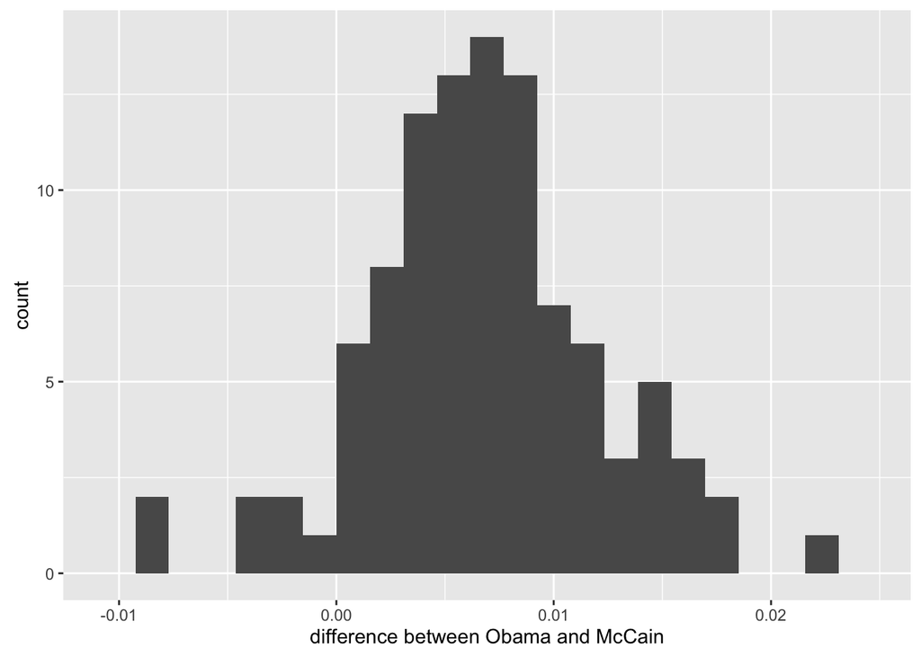

```r
N = 100
set.seed(1234)
qplot(rnorm(N,mu_post,sd_post), geom = "histogram", bins = 20,
      xlab = "difference between Obama and McCain")
```

We see that in some cases the difference is below 0, but the distribution is centered at `mu_post`. We can count the number of times Obama beat McCain from our observations generated from the posterior distribution.

```r
N = 100
set.seed(1234)
mean(rnorm(N,mu_post,sd_post) > 0)
```

```
## [1] 0.91
```

Now let’s put it all together in a Monte Carlo simuation to generate election results.

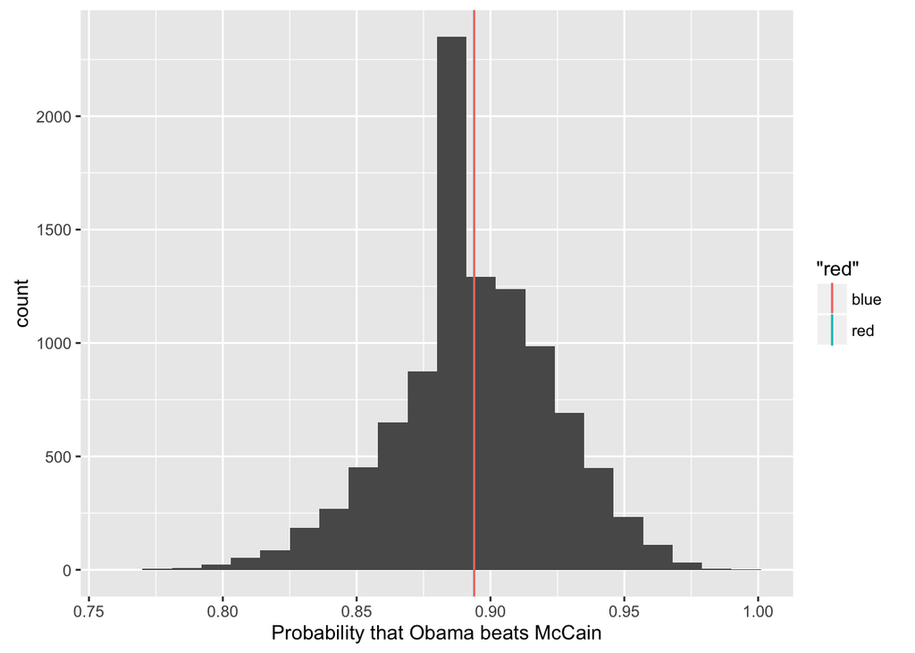

```r
N = 100
B = 1e4
results <- replicate(B, {
    X <- mean(rnorm(N,mu_post,sd_post) > 0)
})
qplot(results, geom = "histogram", bins = 20,
      xlab = "Probability that Obama beats McCain") +
    geom_vline(aes(xintercept = mean(results), color = "red")) +
    geom_vline(aes(xintercept = 1 - pnorm(0, mu_post, sd_post), color = "blue"))
```

```r
mean(results)
```

```
## [1] 0.893852
```

```r
1 - pnorm(0, mu_post, sd_post)
```

```
## [1] 0.8939485
```

#### Assessment

Next, assume there is a general poll bias that is a random variable. It can go either way. How can you add this to your simulation? How does it affect the distribution?

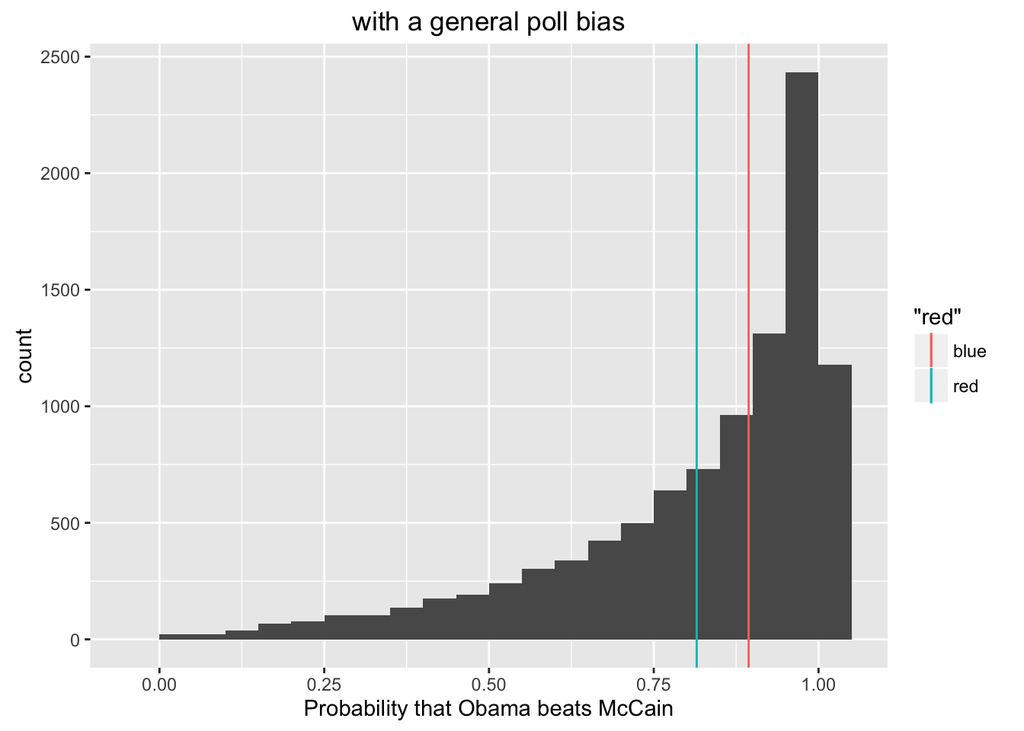

```r
##Your code here.

N = 100
B = 1e4
biassd = 0.005
results <- replicate(B, {
    X <- mean( (rnorm(N,mu_post,sd_post) +
                rnorm(1, 0, biassd))> 0)
})
qplot(results, geom = "histogram", bins = 20,
      xlab = "Probability that Obama beats McCain",
      main = "with a general poll bias") +
    geom_vline(aes(xintercept = mean(results), color = "red")) +
    geom_vline(aes(xintercept = 1 - pnorm(0, mu_post, sd_post), color = "blue"))
```

```r
mean(results)
```

```
## [1] 0.815117
```

```r
1 - pnorm(0, mu_post, sd_post)
```

```
## [1] 0.8939485
```